[OHI British Columbia](http://www.ohibc.org/) | [OHI Science](http://ohi-science.org) | [Citation policy](https://github.com/OHI-Science/ohiprep/releases)

# sf vs sp spatial packages

Compiled on Wed Jul 12 15:39:40 2017 by ohara

```r
knitr::opts_chunk$set(fig.width = 6, fig.height = 4, fig.path = 'Figs/',
                      echo = TRUE, message = FALSE, warning = FALSE)

library(rgdal)
library(sf)
library(tmap)

source('~/github/ohibc/src/R/common.R')  ### an OHIBC specific version of common.R;
  ### includes library(tidyverse); library(stringr)
```

# 1 References

- [Simple features for R, part 1](https://cran.r-project.org/web/packages/sf/vignettes/sf1.html)
- [Simple features for R, part 2: Reading, Writing and Converting Simple Features](https://cran.r-project.org/web/packages/sf/vignettes/sf2.html)
- [Simple features for R, part 3: Manipulating Simple Feature Geometries](https://cran.r-project.org/web/packages/sf/vignettes/sf3.html)
- [Simple Features for R v0.5-1](https://www.rdocumentation.org/packages/sf/versions/0.5-1)
- [First impressions from `sf` – the simple features R package](https://geographicdatascience.com/2017/01/06/first-impressions-from-sf-the-simple-features-r-package/)
- [Tidying feature geometries with `sf`](http://r-spatial.org/r/2017/03/19/invalid.html)
- [Tidy spatial data in R: using dplyr, tidyr, and ggplot2 with `sf`](http://strimas.com/r/tidy-sf/)
- [sf - plot, graticule, transform, units, cast, is](http://r-spatial.org/r/2017/01/12/newssf.html)
- unrelated but this looks rad: [mapedit - interactively edit spatial data in R](http://r-spatial.org/r/2017/01/30/mapedit_intro.html)

# 2 Methods

## 2.1 Read polygon features

Reading standard shapefiles (OHIBC regions as example) using `sf` package and `rgdal` package (which is based on `sp`).

`sf::read_sf` (or `st_read()`) uses similar grammar to `rgdal::readOGR()`, i.e. specify `dsn` and `layer` arguments rather than just the full path at once.

```r
dir_ohibc   <- path.expand('~/github/ohibc/prep/_spatial')
ohibc_layer <- 'ohibc_rgn'

# system.time(
#   {
#     for (i in 1:50) {
#       ohibc_rgn <- rgdal::readOGR(dir_ohibc, ohibc_layer)
#     }
#   }
# )
### loading ohibc_rgn.shp 50 times = 87.489 seconds
### ~ 1.80 s average

# system.time(
#   {
#     for (i in 1:50) {
#       ohibc_rgn <- sf::read_sf(dir_ohibc, ohibc_layer)
#     }
#   }
# )
### loading ohibc_rgn.shp 50 times = 3.156 seconds
### ~ 0.063 s average
```

Loading the ohibc_rgn.shp file 50 times with each package, on Mazu:

| function call | elapsed time, 50 loads | mean load time |
| --- | --- | --- |
| `rgdal::readOGR()` | 87.489 s | 1.75 s |
| `sf::read_sf()` | 3.156 s | 0.063 s |

Based on this, `sf::read_sf()` is about 30 x faster than `rgdal::readOGR()`.

## 2.2 Write polygon features

`sf::write_sf()` seems to have an issue with `dsn` directories with existing shapefiles. If the only shapefile is the same one I am writing to, it seems to delete it and overwrite as default. But if another shapefile (with another name) is in there, it chokes and gives the error:

```
Error in CPL_write_ogr(obj, dsn, layer, driver, as.character(dataset_options),  :
  Dataset already exists.
```

You can get around this by creating a temp folder, writing to that, then copying over when you are done, but hopefully a future version of the `sf` package will just fix this to a better system.

```r
# dir_ohibc   <- path.expand('~/github/ohibc/prep/_spatial')
# ohibc_layer <- 'ohibc_rgn'
#
# dir.create('sf_sp_testing')
# dir_tmpsave <- path.expand('~/github/ohibc/sf_sp_testing')
#
# ohibc_spdf <- rgdal::readOGR(dir_ohibc, ohibc_layer)

# system.time(
#   {
#     for (i in 1:50) {
#       writeOGR(ohibc_spdf,
#                dir_tmpsave, ohibc_layer,
#                driver = 'ESRI Shapefile',
#                overwrite_layer = TRUE)
#     }
#   }
# )
### writing ohibc_rgn.shp 50 times = 125.551 seconds
### ~ 2.51 s average

# ohibc_sf   <- sf::read_sf(dir_ohibc, ohibc_layer)

# system.time(
#   {
#     for (i in 1:50) {
#       write_sf(ohibc_sf,
#                dir_tmpsave, ohibc_layer,
#                driver = 'ESRI Shapefile')
#     }
#   }
# )
### writing ohibc_rgn.shp 50 times = 58.179 seconds
### ~ 1.16s average
```

Writing the `ohibc_rgn.shp` file 50 times with each package, on Mazu:

| function call | elapsed time, 50 writes | mean write time |
| --- | --- | --- |
| `rgdal::writeOGR()` | 125.551 s | 2.51 s |
| `sf::write_sf()` | 58.179 s | 1.16 s |

Based on this, `sf::write_sf()` is about 2.2 x faster than `rgdal::writeOGR()`.

## 2.3 Get data from spatial feature

Let’s take a spatial data object and extract the attribute table as a data frame. In SpatialPolygonsDataFrame objects, the data is in the `@data` slot and comes right out as a `data.frame` object. In an `sf` object, the object itself is like a modified data.frame with a geometry column. So for this comparison, I’ll convert the `sf` object to a data.frame and strip the geometry.

Because of those extra operations, it’s much slower (~ 2000 x slower). But this probably isn’t a big issue. On the other hand, `setdiff(x, y)` shows the two resulting dataframes are identical.

```r
# dir_pfmsa   <- file.path(dir_M, 'git-annex/bcprep/_raw_data/dfo_khunter',
#                          'management_boundaries/d2016/pac_fishery_mgmt_subareas')
# pfmsa_layer <- 'DFO_BC_PFMA_SUBAREAS_50K_V3_1'
#
# pfmsa_spdf <- rgdal::readOGR(dir_pfmsa, pfmsa_layer)

# system.time(
#   {
#     for (i in 1:1e8) {
#       x <- pfmsa_spdf@data
#     }
#   }
# )
### getting data from pfmsa_spdf 100 million times = 20.264 seconds
### = 2.0264e-07 s each

# pfmsa_sf   <- sf::read_sf(dir_pfmsa, pfmsa_layer)

# system.time(
#   {
#     for (i in 1:1e5) {
#       y <- pfmsa_sf %>%
#         as.data.frame() %>%
#         select(-geometry)
#     }
#   }
# )
### getting data from pfmsa_sf 100,000 times = 46.705 seconds
### = 4.6705e-4 s each
```

## 2.4 Functions operating on features

### 2.4.1 Area calculation

`sf::st_area()` vs `rgeos::gArea()`

- `rgeos::gArea()`:
  - needs `byid = TRUE` if you want areas for each feature
  - returns vector of unitless numbers
- `sf::st_area()`:
  - returns areas for each feature by default
  - returns vector of class ‘units’ with numbers.

```r
dir_ohibc   <- path.expand('~/github/ohibc/prep/_spatial')
ohibc_layer <- 'ohibc_rgn'

ohibc_spdf <- rgdal::readOGR(dir_ohibc, ohibc_layer)
ohibc_sf   <- sf::read_sf(dir_ohibc, ohibc_layer)


dir_pfmsa   <- file.path(dir_M, 'git-annex/bcprep/_raw_data/dfo_khunter',
                         'management_boundaries/d2016/pac_fishery_mgmt_subareas')
pfmsa_layer <- 'DFO_BC_PFMA_SUBAREAS_50K_V3_1'

pfmsa_spdf <- rgdal::readOGR(dir_pfmsa, pfmsa_layer)
pfmsa_sf   <- sf::read_sf(dir_pfmsa, pfmsa_layer)
```

```r
x <- rgeos::gArea(ohibc_spdf, byid = TRUE)
x
```

```
##            0            1            2            3            4
##  28162406566   8159221123  17519936788  46053741067  20517013399
##            5            6            7
##  13731588963   3210947740 315888121302
```

```r
y <- sf::st_area(ohibc_sf)
y
```

```
## Units: m^2
## [1]  28162406566   8159221123  17519936788  46053741067  20517013399
## [6]  13731588963   3210947740 315888121302
```

```
x <- rgeos::gArea(ohibc_spdf, byid = TRUE)
#           0            1            2            3            4            5            6            7
# 28162406566   8159221123  17519936788  46053741067  20517013399  13731588963   3210947740 315888121302

y <- sf::st_area(ohibc_sf)
# Units: m^2
# [1]  28162406566   8159221123  17519936788  46053741067  20517013399  13731588963   3210947740 315888121302
```

To compare the results, coercing the `units` vector into numeric, and finding the difference between the two:

```r
x - as.numeric(y)
```

```
##             0             1             2             3             4
##  7.247925e-05 -5.655289e-04  8.659363e-04 -1.449585e-04 -7.629395e-04
##             5             6             7
##  1.716614e-04  4.243851e-05  3.051758e-04
```

```
x - as.numeric(y)
           0             1             2             3             4             5             6             7
7.247925e-05 -5.655289e-04  8.659363e-04 -1.449585e-04 -7.629395e-04  1.716614e-04  4.243851e-05  3.051758e-04
```

Not identical, but pretty damn small differences proportionally:

```r
(x - as.numeric(y)) / x
```

```
##             0             1             2             3             4
##  2.573617e-15 -6.931162e-14  4.942577e-14 -3.147594e-15 -3.718570e-14
##             5             6             7
##  1.250120e-14  1.321682e-14  9.660882e-16
```

### 2.4.2 Simplify and Validity check

It would be good to test the validity check with a known invalid polygon shapefile. Performance wise, `rgeos::gSimplify()` and `sf::st_simplify()` are similar in elapsed time, as are `rgeos::gIsValid()` and `sf::st_is_valid()`.

```r
# system.time({
#   for (i in 1:10) {
#     tmp_spdf <- pfmsa_spdf %>%
#       rgeos::gSimplify(tol = 5)
#   }
# }) ### 2.48 s per iteration

# system.time({
#   for (i in 1:10) {
#     x <- rgeos::gIsValid(tmp_spdf, byid = TRUE)
#   }
# }) ### 1.5 s per iteration

# system.time({
#   for (i in 1:10) {
#     tmp_sf <- pfmsa_sf %>%
#       sf::st_simplify(dTolerance = 5)
#   }
# }) ### 2.26 s per iteration

# system.time({
#   for (i in 1:10) {
#     y <- sf::st_is_valid(tmp_sf)
#   }
# }) ### 1.88 s per iteration.
```

### 2.4.3 Intersection of two features

`rgeos::gIntersection()` returns a SpatialPolygons object but loses the dataframe. `raster::intersect()` (which I believe is built on `rgeos::gIntersection()`) returns a SpatialPolygonsDataFrame and keeps the data from both objects. `sf::st_intersection` returns the `sf` object of intersecting geometries with data from both objects included.

Performance-wise, `st_intersection` and `gIntersection` are pretty close to the same, while `raster::intersect` is considerably slower. But `st_intersection`’s output includes attributes.

- `rgeos::gIntersection()`: 167 s
- `raster::intersect()`: 263 s
- `sf::st_intersection`: 182 s

```r
# system.time({
#   x <- rgeos::gIntersection(ohibc_spdf, pfmsa_spdf, byid = TRUE)
# })
#    user  system elapsed
# 166.976   0.108 167.050

# system.time({
#   y <- raster::intersect(ohibc_spdf, pfmsa_spdf)
# })
#    user  system elapsed
# 263.104   0.192 263.242

# system.time({
#   z <- sf::st_intersection(ohibc_sf, pfmsa_sf)
# })
#    user  system elapsed
# 181.836   0.212 181.996
```

### 2.4.4 Create a Buffer

Testing `rgeos::gBuffer()`, `raster::buffer()`, and `sf::st_buffer()`.

`sf::st_buffer()` seems significantly faster than `rgeos::gBuffer()` and especially `raster::buffer()`, and has the advantage of keeping all the attributes from the objects.

- `rgeos::gBuffer()`: 165 s
- `raster::buffer()`: 534 s
- `sf::st_buffer()`: 102 s (1.6x faster than `rgeos::gBuffer()` and 5x faster than `raster::buffer()`)

```r
# system.time({
#   x <- rgeos::gBuffer(ohibc_spdf, width = 1000, byid = TRUE)
# })
#    user  system elapsed
# 150.572  14.740 165.263

# system.time({
#   y <- raster::buffer(ohibc_spdf, width = 1000)
# })
#    user  system elapsed
# 453.860  80.340 534.053

# system.time({
#   z <- sf::st_buffer(ohibc_sf, dist = 1000)
# })
 #   user  system elapsed
 # 98.584   3.152 101.732
```

## 2.5 Plotting

### 2.5.1 ggplot2 vs tmap: time to create basic plot

*NOTE:* This uses the ggplot2 installed from the `sf` branch…

These are all based on a reasonably simple shapefile.

- `ggplot2` and `Spatial*` objects: **3.357 seconds**
  - Using `ggplot2` to plot `Spatial*` objects requires using `broom::tidy()` or `ggplot2::fortify()` (on its way out) on the object to turn it into a dataframe. This loses the data and is annoying.
  - It also messes up the plots and fills in holes.
  - Don’t do it.
- `tmap` and `Spatial*` objects: **53.912 seconds**
  - no need to modify the `Spatial*` object.
  - use `tm_polygons`, `tm_borders`, or `tm_fill`
  - slower than `ggplot2`, but `ggplot2` is terrible for these objects.
- `ggplot2` and `sf` objects: **1.860 seconds**
  - no need to modify the `sf` object. `sf` objects are pretty much dataframes already!
  - use `geom_sf()`
  - even in a non-degree CRS, it plots the degrees grid behind it. Cool!
  - remarkably faster and looks good! new favorite?
- `tmap` and `sf` objects: **53.635 seconds**
  - no need to modify the `sf` object.
  - use `tm_polygons`, `tm_borders`, or `tm_fill`
  - slower than `ggplot2`; about the same as `tmap` for `Spatial*` objects.

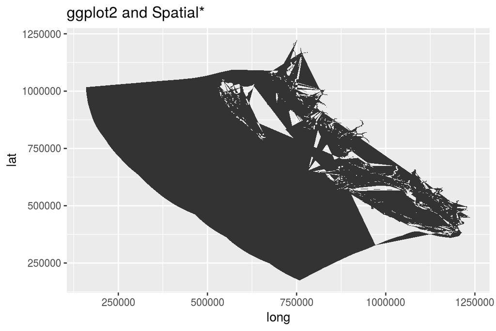

```r
# system.time({
  ohibc_spdf_fort <- broom::tidy(ohibc_spdf)
  x <- ggplot(ohibc_spdf_fort, aes(x = long, y = lat)) +
    geom_polygon() +
    labs(title = 'ggplot2 and Spatial*')
  print(x)
```

```r
# })
#  user  system elapsed
# 2.384   0.976   3.357

# system.time({
  y <- tm_shape(ohibc_spdf) +
    tm_polygons() +
    tm_layout(title = 'tmap and Spatial*')
  print(y)
```

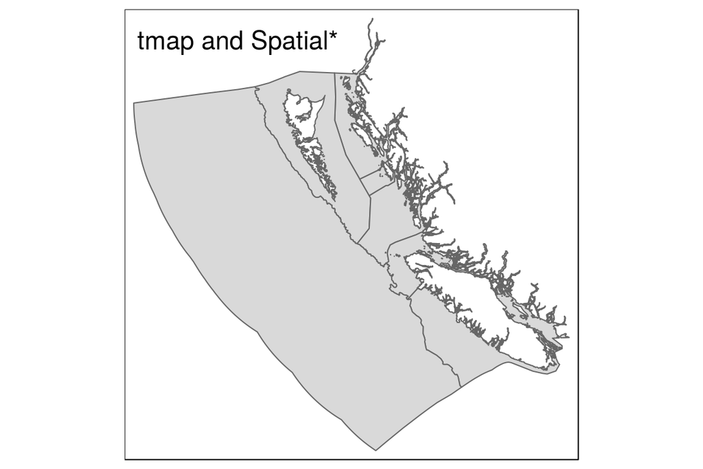

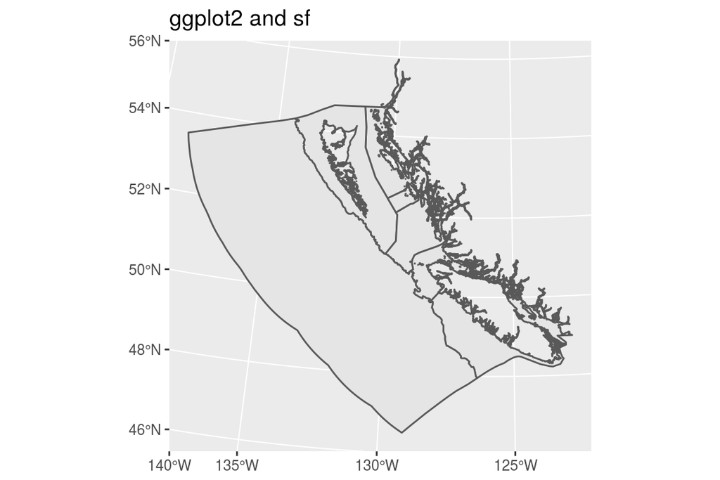

```r
# })
#   user  system elapsed
# 53.752   0.176  53.912

# system.time({
  z <- ggplot(ohibc_sf) +
    geom_sf() +
    labs(title = 'ggplot2 and sf')
  print(z)
```

```r
# })
#  user  system elapsed
# 1.856   0.004   1.860

# system.time({
  w <- tm_shape(ohibc_sf) +
    tm_polygons() +
    tm_layout(title = 'tmap and sf')
  print(w)
```

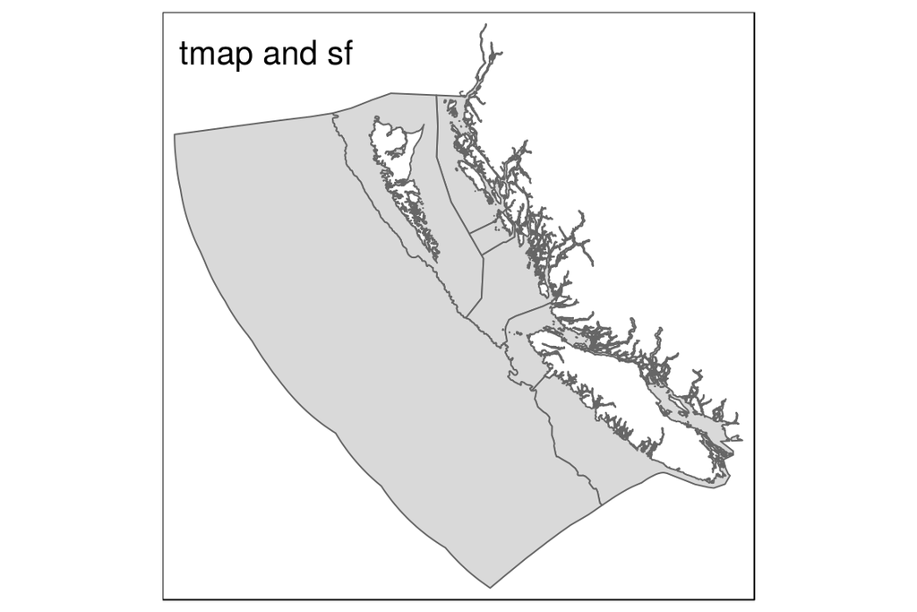

```r
# })
#   user  system elapsed
# 53.424   0.228  53.635
```

## 2.6 geojson vs shp vs other formats

I think there are three arenas in which we want to consider our spatial data:

- saved on disk, or reading from/writing to disk
- in working memory
- in visualizing, especially for interactive maps

### 2.6.1 Disk size

For our purposes, with Mazu, disk size is not super important. For the mid-size OHIBC regions shapefile, let’s read it in and re-save as geojson:

```r
library(geojsonio)
geojsonio::geojson_write(ohibc_spdf, geometry = 'polygon', file = 'ohibc_rgn_tmp.geojson')
```

```
## <geojson>
##   Path:       ohibc_rgn_tmp.geojson
##   From class: SpatialPolygonsDataFrame
```

```r
file.info(file.path(dir_ohibc, 'ohibc_rgn.shp')) ### 9612748 bytes (9.6 MB)
```

```
##                                                         size isdir mode
## /home/ohara/github/ohibc/prep/_spatial/ohibc_rgn.shp 9612748 FALSE  644
##                                                                    mtime
## /home/ohara/github/ohibc/prep/_spatial/ohibc_rgn.shp 2016-09-12 10:14:29
##                                                                    ctime
## /home/ohara/github/ohibc/prep/_spatial/ohibc_rgn.shp 2016-09-12 10:14:29
##                                                                    atime
## /home/ohara/github/ohibc/prep/_spatial/ohibc_rgn.shp 2017-07-12 15:39:46
##                                                       uid  gid uname
## /home/ohara/github/ohibc/prep/_spatial/ohibc_rgn.shp 1011 1011 ohara
##                                                      grname
## /home/ohara/github/ohibc/prep/_spatial/ohibc_rgn.shp  ohara
```

```r
file.info('ohibc_rgn_tmp.geojson') ### 31108544 bytes (31 MB)
```

```
##                           size isdir mode               mtime
## ohibc_rgn_tmp.geojson 31108544 FALSE  644 2017-07-12 15:41:38
##                                     ctime               atime  uid  gid
## ohibc_rgn_tmp.geojson 2017-07-12 15:41:38 2017-07-12 15:41:38 1011 1011
##                       uname grname
## ohibc_rgn_tmp.geojson ohara  ohara
```

```r
unlink('ohibc_rgn_tmp.geojson')
```

The .geojson is actually much larger! so no benefits in saving in that format. We already saw the speed improvements in reading the file using read_sf.

### 2.6.2 RAM

In working memory, it seems like we are talking either `sp` objects (old school) or `sf` objects (new school). [This page on Leaflet](https://rstudio.github.io/leaflet/json.html) seems to indicate that geojson files just get read in as `sp` objects anyway, so reading in a geojson is no different from reading in a shapefile. How much RAM does an `sf` object take up compared to an `sp` object?

```r
object.size(ohibc_spdf) ### 16028856, 16 MB
```

```
## 16028856 bytes
```

```r
object.size(ohibc_sf) ### 10655880, 10 MB
```

```
## 10655880 bytes
```

So a little smaller, by about the same proportion that the buffer test seemed to show in speed improvements.

### 2.6.3 Interactive maps

The key here is just to down-res the maps significantly. Here’s a cool site that provides an interface for shrinking map files: http://mapshaper.org/. You can also use `gSimplify` (in the `rgeos` package, for `sp` objects) or `st_simplify` (in the `sf` package, for `sf` objects). In ohi-global, there is a script lurking to simplify polygons as well; it partly takes advantage of a variant of `gSimplify`, but also identifies and deletes thousands of tiny polygons in the global shapefile that are way too small to worry about on a map.

### 2.6.4 geojson conclusions:

Don’t worry about it. Stick with `.shp` files. Make super simplified versions of maps for interactive displays.

## 2.7 Rasterizing (fasterize vs gdal_rasterize)

The raster package is largely dependent on the `sp` package, and is compatible with `sp` objects. `raster::rasterize()` takes an `sp` object in memory and converts to a `Raster*` object.

`gdalUtils::gdal_rasterize` is independent of `sp`, instead based on GDAL and essentially running a system call at the command line. It takes a spatial file on disk (e.g. .shp), and rasterizes it to a raster on disk (e.g. .tif), and can also return it as a `Raster*` object into working memory.

`fasterize::fasterize()` takes an `sf` object and rasterizes it into working memory, as a `Raster*` object.

```r
rast_base <- raster::raster(file.path(dir_ohibc, 'raster/ohibc_rgn_raster_1000m.tif'))
#
# system.time({
  rast_from_raster <- raster::rasterize(ohibc_spdf, rast_base) #, field = 'rgn_id'])
# }) ### ~ 30 seconds and can't even get it to work with the field argument.
#
raster::writeRaster(rast_from_raster, 'rast_from_raster.tif', overwrite = TRUE)
# file.info('rast_from_raster.tif') ### 1184533 bytes
```

```r
rast_base <- raster::raster(file.path(dir_ohibc, 'raster/ohibc_rgn_raster_1000m.tif'))

source('~/github/ohibc/src/R/rast_tools.R')
source_file <- file.path(dir_ohibc, 'ohibc_rgn.shp')
dest_file <- file.path(getwd(), 'rast_from_gdal_rast2.tif')

# system.time({
  rast_from_gdal_rast2 <- gdal_rast2(src = source_file, rast_base = rast_base, dst = dest_file, value = 'rgn_id', override_p4s = TRUE)
# }) ### ~ 7 seconds
#
# file.info('rast_from_gdal_rast2.tif') ### 1177035 bytes
### Note that the raw gdal_rasterize() file is more like 20 MB, but I re-save
### it using writeRaster to get the benefits of LZW compression
```

```r
rast_base <- raster::raster(file.path(dir_ohibc, 'raster/ohibc_rgn_raster_1000m.tif'))

# system.time({
  rast_from_fasterize <- fasterize::fasterize(ohibc_sf, rast_base, field = 'rgn_id')
# }) ### ~ 0.054 seconds

raster::writeRaster(rast_from_fasterize, 'rast_from_fasterize.tif', overwrite = TRUE)

# file.info('rast_from_fasterize.tif') ### 1184533 bytes
```

### 2.7.1 Plotting rasters:

1. raster generated using `raster::rasterize()`; note that Haida Gwaii is mostly filled in, and the numbers do not correspond with the region IDs (e.g. HG should be 2, not 4)
2. raster generated using `gdalUtils::gdal_rasterize()`, with my own custom wrapper `gdal_rast2()` to make the inputs a little more friendly.
3. raster generated using `fasterize::fasterize()`

Subtracting 2 from 3 results in a raster of zeros: they are identical!

Note: `tmap` seems pretty fast for rasters, just not so much for polygons.

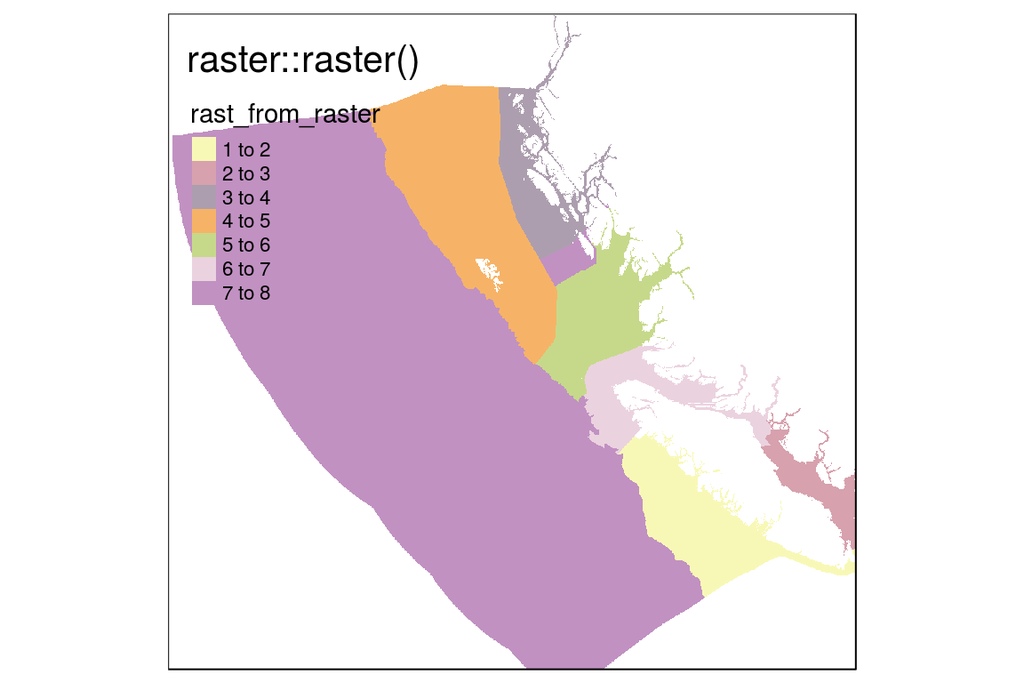

```r
rast_trimmed <- raster::extent(c(xmin = 100000, xmax = 1200000, ymin = 220000, ymax = 1200000))
r1 <- raster::raster('rast_from_raster.tif') %>%
  raster::crop(rast_trimmed)
r2 <- raster::raster('rast_from_gdal_rast2.tif') %>%
  raster::crop(rast_trimmed)
r3 <- raster::raster('rast_from_fasterize.tif') %>%
  raster::crop(rast_trimmed)

r4 <- r3 - r2

tm_shape(r1) + tm_raster(palette = 'Set3') + tm_layout(title = 'raster::raster()')
```

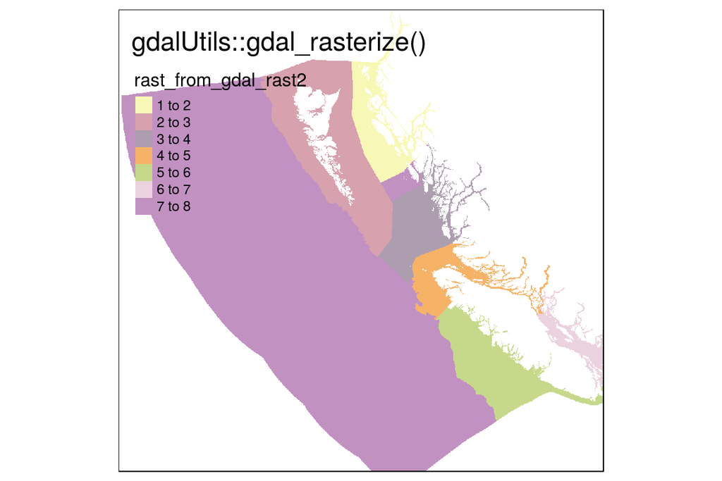

```r
tm_shape(r2) + tm_raster(palette = 'Set3') + tm_layout(title = 'gdalUtils::gdal_rasterize()')
```

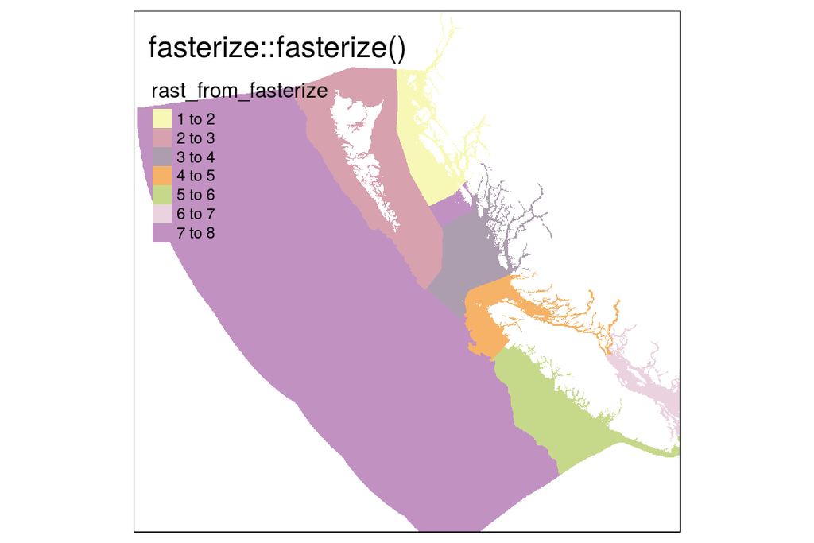

```r
tm_shape(r3) + tm_raster(palette = 'Set3') + tm_layout(title = 'fasterize::fasterize()')
```

```r
unlink(c('rast_from_raster.tif',
         'rast_from_gdal_rast2.tif',
         'rast_from_fasterize.tif'))
```

### 2.7.2 Raster conclusions:

| method | elapsed time | file size | notes |
| --- | --- | --- | --- |
| raster::rasterize | 30 sec | 1.2 MB | requires `sp` object; errors when specifying field; errors in resulting raster |
| gdalUtils::gdal_rasterize | 7 sec | 1.2 MB * | only works from saved spatial file; raw saved file is more like 20 MB without compression |
| fasterize::fasterize | 0.054 sec | 1.2 MB | requires `sf` object; WAYYYYYYY faster; returns regular `Raster*` object but doesn’t save to disk |

So: use `fasterize::fasterize` where possible. Do not use `raster::rasterize()` without carefully checking the results!!!